# **Forecasting Global University Rankings: A Data-Driven Predictive Model for Evaluating Future Performance**

**Mid Report Submission**

**Course Title & Code:** Data Science (CS 8339)

**Group Members:**

1. Engr. Priha Bhatti FA23-PHCS-0001
2. Erum Mumtaz SP22-PHCS-0003
3. Mirza Shaharyar Ali Baig FA22-MSCS-0037

**Description and Objectives of Project**

Domain Name: Education/Academics (University)-Global University Ranking: Our Project work is related to academics where we are going to predict the ranking of the World's top universities with respect to some attributes. By getting insights into business questions according to applying different models we get answers from data and create a complete outcome or report in the form of a dashboard.

**About Dataset** The World University Rankings 2023 dataset include 1,799 universities across 104 countries and regions, making them the largest and most diverse university rankings to date. The table is based on 13 carefully calibrated performance indicators that measure an institution’s performance across four areas: teaching, research, knowledge transfer and international outlook. This year’s ranking analyzed over 121 million citations across more than 15.5 million research publications and included survey responses from 40,000 scholars globally. Overall, we collected over 680,000 datapoints from more than 2,500 institutions that submitted data.

**Features** This dataset includes the following 13 features: 1)University Rank 2)Name of University 3)Location 4)No of student 5)No of student per staff 6)International Student 7)Female :Male Ratio 8)OverAll Score 9)Teaching Score 10)Research Score 11)Citations Score 12)Industry Income Score 13)International Outlook Score

• Name of University:

This attribute refers to the name or title of the university, identifying each institution uniquely within the dataset. For instance, "Harvard University," "University of Oxford," etc.

• Location:

It signifies the geographic location or address of the university. This could include details such as city, state, and country where the university is situated.

• Number of Students:

This attribute typically represents the total count of enrolled students at the university. It provides the overall student population or enrollment figure for a given period.

• Number of Students per Staff:

This metric represents the ratio of students to academic or administrative staff members at the university. It provides an insight into the student-to-faculty ratio, indicating how many students are managed per staff member.

• International Students:

This attribute denotes the count or percentage of students at the university who come from countries other than the one where the university is located. It signifies the diversity and internationalization of the student body.

• Female to Male Ratio:

This figure represents the proportion or ratio of female students to male students at the university. For example, a ratio of 1:1 would signify an equal number of male and female students.

• Overall Score:

This is an aggregated score that reflects the overall performance or ranking of the university. It's usually a comprehensive score derived from various individual metrics.

• Teaching Score:

This metric assesses the quality of teaching and the educational experience provided by the university. It could include teaching methodologies, student satisfaction, and educational resources.

• Research Score:

This score indicates the university's excellence and output in research activities, such as publications, patents, research grants, etc.

• Citations Score:

This score relates to the impact of the university's research by measuring how often its academic work is cited by others in scholarly publications.

• Industry Income Score:

This metric signifies the university's ability to generate income through industry partnerships, research collaborations, or commercialization of research.

• International Outlook Score:

This score evaluates the global outlook and international collaboration of the university, considering factors like international partnerships, student exchange programs, and global engagement.

These attributes collectively provide comprehensive insights into various aspects of universities, including their academic performance, student demographics, international diversity, and overall standing in the global academic landscape.

# **1. Exploratory Data Analysis**

**1.1 Import Necessary Libraries**

```python
import numpy as np # linear algebra
import pandas as pd # data processing, CSV file I/O (e.g. pd.read_csv)
import matplotlib.pyplot as plt#a cross-platform, data visualization and graphical plotting library (histograms, scatter plots, bar charts, etc) for Python and its numerical extension NumPy
import seaborn as sns#a Python data visualization library based on matplotlib
```

**1.2 Load The Dataset**

```python
# Loading the dataset into a pandas DataFrame
data = pd.read_csv("/content/drive/MyDrive/World University Rankings 2023.csv")

# Displaying the first few rows of the dataset to get an overview
data.head()
```

|  | University Rank | Name of University | Location | No of student | No of student per staff | International Student | Female:Male Ratio | OverAll Score | Teaching Score | Research Score | Citations Score | Industry Income Score | International Outlook Score |
| --- | --- | --- | --- | --- | --- | --- | --- | --- | --- | --- | --- | --- | --- |
| 0 | 1 | University of Oxford | United Kingdom | 20,965 | 10.6 | 42% | 48 : 52 | 96.4 | 92.3 | 99.7 | 99.0 | 74.9 | 96.2 |
| 1 | 2 | Harvard University | United States | 21,887 | 9.6 | 25% | 50 : 50 | 95.2 | 94.8 | 99.0 | 99.3 | 49.5 | 80.5 |
| 2 | 3 | University of Cambridge | United Kingdom | 20,185 | 11.3 | 39% | 47 : 53 | 94.8 | 90.9 | 99.5 | 97.0 | 54.2 | 95.8 |
| 3 | 3 | Stanford University | United States | 16,164 | 7.1 | 24% | 46 : 54 | 94.8 | 94.2 | 96.7 | 99.8 | 65.0 | 79.8 |
| 4 | 5 | Massachusetts Institute of Technology | United States | 11,415 | 8.2 | 33% | 40 : 60 | 94.2 | 90.7 | 93.6 | 99.8 | 90.9 | 89.3 |

```python
data.columns # checks the features of Dataset
len(data.columns)
```

```
13
```

**1.3 Descriptive Statistics**

This code calculates statistical measures such as mean, median, standard deviation, and range for each numerical column present in the dataset.

```python
# Obtaining descriptive statistics for the dataset
desc_stats = data.describe()

# Displaying the descriptive statistics
desc_stats
```

|  | No of student per staff | Teaching Score | Research Score | Citations Score | Industry Income Score | International Outlook Score |
| --- | --- | --- | --- | --- | --- | --- |
| count | 2208.000000 | 1799.000000 | 1799.000000 | 1799.000000 | 1799.000000 | 1799.000000 |
| mean | 19.000408 | 27.018010 | 23.016898 | 48.495887 | 47.104558 | 46.880378 |
| std | 12.132224 | 13.282243 | 16.763819 | 27.967185 | 15.093682 | 22.582401 |
| min | 0.400000 | 11.600000 | 7.400000 | 0.800000 | 36.900000 | 14.100000 |
| 25% | 12.600000 | 18.000000 | 11.300000 | 23.100000 | 37.800000 | 27.900000 |
| 50% | 16.600000 | 22.700000 | 17.000000 | 47.200000 | 40.500000 | 42.100000 |
| 75% | 22.200000 | 31.850000 | 28.900000 | 72.350000 | 48.300000 | 62.100000 |
| max | 232.200000 | 94.800000 | 99.700000 | 100.000000 | 100.000000 | 99.700000 |

# **2. Data Preprocessing**

**Data Exploration** Data exploration involves analyzing and visualizing data to understand its structure, patterns, and relationships. Here are some common techniques and tools used for data exploration:

Sure, here are the key points in bullet format:

Summary Statistics:

Use describe() for numerical columns.

Data Types and Missing Values:

Utilize info() to get data types and missing value information.

Histograms:

Visualize numerical variable distributions with histograms.

Box Plots:

Identify outliers and assess data spread using box plots.

Correlation Analysis:

Explore relationships with correlation matrices and heatmaps.

Pair Plots:

Visualize relationships among multiple numerical variables.

Value Counts:

Understand the distribution of categorical variables using value_counts().

Bar Charts:

Create bar charts to visualize categorical variable distributions.

Scatter Plots:

Explore relationships between two numerical variables.

Heatmaps:

Visualize patterns and relationships in a matrix of numerical data.

Data exploration is an iterative process involving these techniques to gain insights, identify patterns, and inform subsequent steps in data analysis or modeling.

```python
data.isna().sum()#computes the sum of missing values for each column in the dataset named 'data'.
```

```
University Rank                  0
Name of University             108
Location                       294
No of student                  132
No of student per staff        133
International Student          132
Female:Male Ratio              213
OverAll Score                  542
Teaching Score                 542
Research Score                 542
Citations Score                542
Industry Income Score          542
International Outlook Score    542
dtype: int64
```

```python
print(data.dtypes)#outputs the data types of each column in the dataset named 'data'.
```

```
University Rank                 object
Name of University              object
Location                        object
No of student                   object
No of student per staff        float64
International Student           object
Female:Male Ratio               object
OverAll Score                   object
Teaching Score                 float64
Research Score                 float64
Citations Score                float64
Industry Income Score          float64
International Outlook Score    float64
dtype: object
```

```python
data.info()#provides a concise summary of the information about the dataset 'data', including the data types, non-null counts, and memory usage.
```

```
<class 'pandas.core.frame.DataFrame'>
RangeIndex: 2341 entries, 0 to 2340
Data columns (total 13 columns):
 #   Column                       Non-Null Count  Dtype
---  ------                       --------------  -----
 0   University Rank              2341 non-null   object
 1   Name of University           2233 non-null   object
 2   Location                     2047 non-null   object
 3   No of student                2209 non-null   object
 4   No of student per staff      2208 non-null   float64
 5   International Student        2209 non-null   object
 6   Female:Male Ratio            2128 non-null   object
 7   OverAll Score                1799 non-null   object
 8   Teaching Score               1799 non-null   float64
 9   Research Score               1799 non-null   float64
 10  Citations Score              1799 non-null   float64
 11  Industry Income Score        1799 non-null   float64
 12  International Outlook Score  1799 non-null   float64
dtypes: float64(6), object(7)
memory usage: 237.9+ KB
```

```python
data.shape#returns a tuple representing the dimensions of the dataset 'data', where the first element is the number of rows and the second element is the number of columns.
```

```
(2341, 13)
```

```python
#data.describe().T#transposes the summary statistics generated by the describe() method for the dataset 'data', providing a more readable format where statistics are presented for each column in rows.
```

```python
#data.describe(include = 'object').T#generates summary statistics for columns with object data type in the dataset 'data', providing information such as count, unique, top, and frequency for each of those columns in a transposed format for better readability.
```

```python
duplicate_rows = data[data.duplicated(keep='first')]
num_duplicates = duplicate_rows.shape[0]#The code identifies and counts duplicate rows in the dataset 'data' using data.duplicated(keep='first'). The resulting DataFrame duplicate_rows contains the duplicated rows, and the variable num_duplicates holds the count of these duplicates. The parameter keep='first' retains the first occurrence of each duplicated row.
print(f"Number of duplicate rows: {num_duplicates}")
duplicate_rows#outputs the number of duplicate rows in the dataset 'data', and duplicate_rows is a DataFrame containing those duplicated rows.
```

```
Number of duplicate rows: 29
```

|  | University Rank | Name of University | Location | No of student | No of student per staff | International Student | Female:Male Ratio | OverAll Score | Teaching Score | Research Score | Citations Score | Industry Income Score | International Outlook Score |
| --- | --- | --- | --- | --- | --- | --- | --- | --- | --- | --- | --- | --- | --- |
| 2288 | - | NaN | NaN | NaN | NaN | NaN | NaN | NaN | NaN | NaN | NaN | NaN | NaN |
| 2289 | - | NaN | NaN | NaN | NaN | NaN | NaN | NaN | NaN | NaN | NaN | NaN | NaN |
| 2290 | - | NaN | NaN | NaN | NaN | NaN | NaN | NaN | NaN | NaN | NaN | NaN | NaN |
| 2291 | - | NaN | NaN | NaN | NaN | NaN | NaN | NaN | NaN | NaN | NaN | NaN | NaN |
| 2292 | - | NaN | NaN | NaN | NaN | NaN | NaN | NaN | NaN | NaN | NaN | NaN | NaN |
| 2293 | - | NaN | NaN | NaN | NaN | NaN | NaN | NaN | NaN | NaN | NaN | NaN | NaN |
| 2294 | - | NaN | NaN | NaN | NaN | NaN | NaN | NaN | NaN | NaN | NaN | NaN | NaN |
| 2295 | - | NaN | NaN | NaN | NaN | NaN | NaN | NaN | NaN | NaN | NaN | NaN | NaN |
| 2296 | - | NaN | NaN | NaN | NaN | NaN | NaN | NaN | NaN | NaN | NaN | NaN | NaN |
| 2297 | - | NaN | NaN | NaN | NaN | NaN | NaN | NaN | NaN | NaN | NaN | NaN | NaN |
| 2298 | - | NaN | NaN | NaN | NaN | NaN | NaN | NaN | NaN | NaN | NaN | NaN | NaN |
| 2299 | - | NaN | NaN | NaN | NaN | NaN | NaN | NaN | NaN | NaN | NaN | NaN | NaN |
| 2300 | - | NaN | NaN | NaN | NaN | NaN | NaN | NaN | NaN | NaN | NaN | NaN | NaN |
| 2301 | - | NaN | NaN | NaN | NaN | NaN | NaN | NaN | NaN | NaN | NaN | NaN | NaN |
| 2302 | - | NaN | NaN | NaN | NaN | NaN | NaN | NaN | NaN | NaN | NaN | NaN | NaN |
| 2303 | - | NaN | NaN | NaN | NaN | NaN | NaN | NaN | NaN | NaN | NaN | NaN | NaN |
| 2304 | - | NaN | NaN | NaN | NaN | NaN | NaN | NaN | NaN | NaN | NaN | NaN | NaN |
| 2305 | - | NaN | NaN | NaN | NaN | NaN | NaN | NaN | NaN | NaN | NaN | NaN | NaN |
| 2306 | - | NaN | NaN | NaN | NaN | NaN | NaN | NaN | NaN | NaN | NaN | NaN | NaN |
| 2307 | - | NaN | NaN | NaN | NaN | NaN | NaN | NaN | NaN | NaN | NaN | NaN | NaN |
| 2308 | - | NaN | NaN | NaN | NaN | NaN | NaN | NaN | NaN | NaN | NaN | NaN | NaN |
| 2309 | - | NaN | NaN | NaN | NaN | NaN | NaN | NaN | NaN | NaN | NaN | NaN | NaN |
| 2310 | - | NaN | NaN | NaN | NaN | NaN | NaN | NaN | NaN | NaN | NaN | NaN | NaN |
| 2311 | - | NaN | NaN | NaN | NaN | NaN | NaN | NaN | NaN | NaN | NaN | NaN | NaN |
| 2312 | - | NaN | NaN | NaN | NaN | NaN | NaN | NaN | NaN | NaN | NaN | NaN | NaN |
| 2313 | - | NaN | NaN | NaN | NaN | NaN | NaN | NaN | NaN | NaN | NaN | NaN | NaN |
| 2314 | - | NaN | NaN | NaN | NaN | NaN | NaN | NaN | NaN | NaN | NaN | NaN | NaN |
| 2315 | - | NaN | NaN | NaN | NaN | NaN | NaN | NaN | NaN | NaN | NaN | NaN | NaN |
| 2316 | - | NaN | NaN | NaN | NaN | NaN | NaN | NaN | NaN | NaN | NaN | NaN | NaN |

Number of duplicate rows: 29

```python
# Assuming 'old_column_name' is the current column name and 'new_column_name' is the desired new column name
data.rename(columns={'Location': 'Country'}, inplace=True)
```

```python
data.info()
```

```
<class 'pandas.core.frame.DataFrame'>
RangeIndex: 2341 entries, 0 to 2340
Data columns (total 13 columns):
 #   Column                       Non-Null Count  Dtype
---  ------                       --------------  -----
 0   University Rank              2341 non-null   object
 1   Name of University           2233 non-null   object
 2   Country                      2047 non-null   object
 3   No of student                2209 non-null   object
 4   No of student per staff      2208 non-null   float64
 5   International Student        2209 non-null   object
 6   Female:Male Ratio            2128 non-null   object
 7   OverAll Score                1799 non-null   object
 8   Teaching Score               1799 non-null   float64
 9   Research Score               1799 non-null   float64
 10  Citations Score              1799 non-null   float64
 11  Industry Income Score        1799 non-null   float64
 12  International Outlook Score  1799 non-null   float64
dtypes: float64(6), object(7)
memory usage: 237.9+ KB
```

# **3. Data Cleaning**

**3.1 Handling Missing values and Null Values**

```python
data=data.dropna()#removes rows with any missing values from the dataset 'data'. The subsequent code
data.shape# returns the new dimensions of the dataset after the removal of rows with missing values.
```

```
(1488, 13)
```

```python
missing_values = data.isnull().sum()
missing_values = missing_values[missing_values > 0]
print(missing_values)#calculates the number of missing values for each column in the dataset 'data'. The subsequent lines filter and print only those columns that have missing values (count greater than 0). The result is a list of columns with their respective counts of missing values.
```

```
Series([], dtype: int64)
```

```python
# Impute missing values in categorical columns with the median
data.fillna(data.median().iloc[0], inplace=True)
data.isna().sum()
```

```
University Rank                0
Name of University             0
Country                        0
No of student                  0
No of student per staff        0
International Student          0
Female:Male Ratio              0
OverAll Score                  0
Teaching Score                 0
Research Score                 0
Citations Score                0
Industry Income Score          0
International Outlook Score    0
dtype: int64
```

```python
data.isna().sum()#after imputing missing values, it should show all columns with a sum of 0, indicating that there are no missing values in those columns anymore. This is assuming you have successfully imputed or filled in the missing values using one of the methods mentioned earlier.
```

```
University Rank                0
Name of University             0
Country                        0
No of student                  0
No of student per staff        0
International Student          0
Female:Male Ratio              0
OverAll Score                  0
Teaching Score                 0
Research Score                 0
Citations Score                0
Industry Income Score          0
International Outlook Score    0
dtype: int64
```

**3.2 Changing the data types of the features**

Certainly! Here are the key points in list form:

Convert to Numeric:

pd.to_numeric(data['Numeric_Column'], errors='coerce')

Convert to Categorical:

data['Categorical_Column'].astype('category')

Convert to Datetime:

pd.to_datetime(data['Date_Column'])

Convert to String:

data['String_Column'].astype(str)

Convert to Boolean:

data['Boolean_Column'].astype(bool)

Convert to Int or Float:

data['Numeric_Column'].astype(int)

Convert to Ordinal:

data['Ordinal_Column'].astype('category', ordered=True)

Convert to Object:

data['Mixed_Column'].astype(object)

Ensure that the chosen data type aligns with the nature of the data and the requirements of your analysis or modeling task.

```python
#cleaning and converting the 'International Student' column in the 'data' DataFrame. Specifically:
data['International Student'] = data['International Student'].str.replace('%', ' ')#This line converts the values in the 'International Student' column to numeric format
data['International Student'] = pd.to_numeric(data['International Student'], errors='coerce')# parameter is used to handle any non-numeric values by converting them to NaN (Not a Number).
#After executing these lines, the 'International Student' column should contain numeric values without the percentage sign, and any non-numeric values would be represented as NaN.
```

```python
data['International Student']=  data['International Student']/100 #dividing all the values in the 'International Student' column by 100. This operation is likely applied to convert the values from percentage format (e.g., 25%) to decimal format (e.g., 0.25). After executing this line, the 'International Student' column will contain values in decimal form, representing the proportion of international students.
```

```python
# Drop the 'Male' and 'Female' columns
data = data.drop(['Female:Male Ratio'], axis=1)
```

```python
# Remove non-numeric characters and ensure only one decimal point in 'OverAll Score' column
data['OverAll Score'] = data['OverAll Score'].str.replace(r'[^0-9.]', '', regex=True)
data['OverAll Score'] = data['OverAll Score'].str.replace(r'\.(?=.*\.)', '', regex=True).astype(float)
```

```python
# Check the updated data types
print(data.dtypes)
```

```
University Rank                 object
Name of University              object
Country                         object
No of student                   object
No of student per staff        float64
International Student          float64
OverAll Score                  float64
Teaching Score                 float64
Research Score                 float64
Citations Score                float64
Industry Income Score          float64
International Outlook Score    float64
dtype: object
```

# **4. Data Visualization**

Data visualization is a crucial aspect of data exploration and analysis, helping to communicate patterns, trends, and insights in a clear and effective manner. Here are some common types of data visualizations and the corresponding Python code using popular libraries like Matplotlib and Seaborn:

Line Plot:

A line plot displays data points on a two-dimensional plane, connecting them with straight lines. It is commonly used to show trends over a continuous variable.

Scatter Plot:

A scatter plot visualizes the relationship between two continuous variables. Each data point is represented by a dot on the graph, allowing for the observation of patterns or correlations.

Histogram:

A histogram represents the distribution of a single numerical variable by dividing it into bins and displaying the frequency of data points in each bin. It provides insights into the data's central tendency and spread.

Box Plot:

A box plot, or box-and-whisker plot, depicts the distribution of numerical data and displays the median, quartiles, and potential outliers. It helps identify the spread and central tendency of the data.

Bar Chart:

A bar chart illustrates the comparison of categorical variables by representing each category with a bar. The height of the bar corresponds to the frequency or proportion of data points in that category.

Heatmap:

A heatmap is a graphical representation of data in a matrix format, where values are represented as colors. It is often used to visualize relationships, patterns, or correlations in large datasets.

Pair Plot:

A pair plot creates a matrix of scatter plots to explore relationships between multiple numerical variables. It helps identify patterns and correlations across different pairs of features.

Violin Plot:

A violin plot combines aspects of a box plot and a kernel density plot. It displays the distribution of numerical data, providing insights into both central tendency and spread.

Pie Chart:

A pie chart represents the proportion of different categories in a dataset. Each category is represented as a slice of the pie, and the size of each slice corresponds to the proportion of data points in that category.

# **Visulization of scores of feature**

Visualization of scores of features refers to the graphical representation of numerical values associated with different features in a dataset. In data analysis and machine learning, a dataset typically comprises various features (also known as variables or attributes), and each instance or data point is described by a set of values corresponding to these features. Visualization helps analysts and researchers to gain insights into the distribution, patterns, and relationships within the data.

**Getting Key Insights using visualizations** Getting key insights using visualizations involves using graphical representations of data to uncover patterns, trends, and relationships that may not be immediately apparent in raw datasets. Visualization is a powerful tool in data analysis and exploration, allowing analysts and decision-makers to derive actionable insights from complex information.

**Distribution of students based on frequency**

The distribution of students based on frequency refers to the arrangement and representation of the number of students in different categories or groups, often expressed as a frequency distribution. This type of distribution provides insights into how many students fall into specific ranges or intervals within a given dataset.

[figure not shown]

```python
# Plot a histogram of 'No of student'
plt.figure(figsize=(6, 4))
sns.histplot(data=data, x='No of student', bins=20, kde=True)
plt.title('Distribution of No of students')
plt.xlabel('No of students')
plt.ylabel('Frequency')
plt.show()
```

Defining the "overall score" for universities typically involves considering multiple factors and criteria, such as academic reputation, faculty qualifications, student-to-faculty ratio, research output, international diversity, and more. Various organizations produce university rankings by aggregating scores based on their chosen criteria.

[figure not shown]

```python
top_universities = data.sort_values(by='OverAll Score', ascending=False).head(10)

# Create a bar plot for the top universities
plt.figure(figsize=(6, 4))
sns.barplot(x='OverAll Score', y='Name of University', data=top_universities, palette='viridis')
plt.title('Top Universities by Overall Score')
plt.xlabel('Overall Score')
plt.ylabel('University')
plt.show()
```

**Relationship between Teaching score and Research score**

The relationship between teaching score and research score typically refers to the correlation or connection between an individual's or an institution's performance in teaching and research activities in the field of education. This relationship is often explored in the context of academic institutions, such as universities and colleges, where teaching and research are two primary components of their mission.

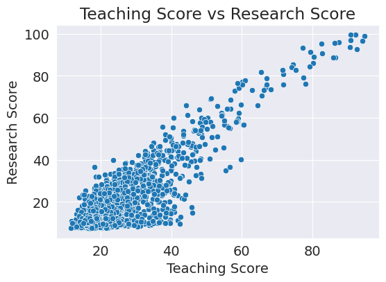

```python
# Plot a scatterplot of 'Teaching Score' vs 'Research Score'
plt.figure(figsize=(6, 4))
sns.scatterplot(data=data, x='Teaching Score', y='Research Score')
plt.title('Teaching Score vs Research Score')
plt.xlabel('Teaching Score')
plt.ylabel('Research Score')
plt.show()
```

The distribution of variance of the top 10 universities by research score refers to how the research scores are spread or dispersed among the top 10 universities in a particular ranking. Variance is a statistical measure that quantifies the degree of spread or dispersion in a set of values. In the context of university rankings, the research score reflects the institutions' research performance, productivity, and impact.

[figure not shown]

```python
top_5_universities = data["Name of University"][:10]
top_5_scores=data["Research Score"][:10]

# Plot a barplot of 'top 10 universities' vs 'Research Score'
plt.figure(figsize=(6, 4))
sns.barplot(data=data, x='Name of University', y='Research Score')
plt.title('top 10 universities by Research Score')
plt.xlabel('Name of University')
plt.ylabel('Research Score')
plt.show()
```

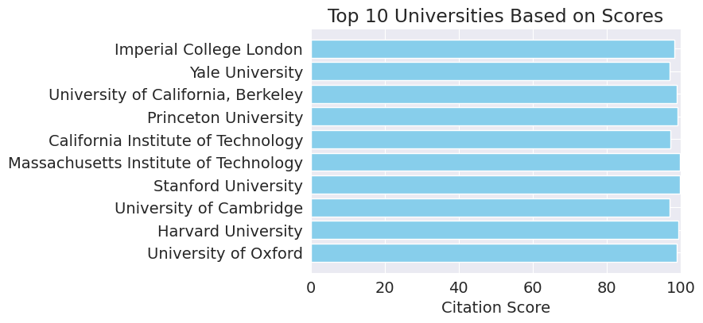

```python
top_10_universities = data["Name of University"][:10]
top_10_scores =data["Citations Score"][:10]

# Create a bar chart for the top 10 universities
plt.figure(figsize=(6, 4))
plt.barh(top_10_universities[::-1], top_10_scores[::-1], color='skyblue')
plt.xlabel('Citation Score')
plt.title('Top 10 Universities Based on Scores')
plt.xlim(0, 100)  # Customize the score range as needed
plt.gca().invert_yaxis()  # Reverse the order to show the top university at the top
plt.show()
```

**Top 10 Universities based on Overall score**

The term "Overall Score" in the context of university rankings refers to a composite score that takes into account various factors and indicators to assess the overall performance and reputation of a university. University rankings are often created by aggregating scores from multiple criteria, such as academic reputation, faculty-to-student ratio, research output, international outlook, teaching quality, and more.

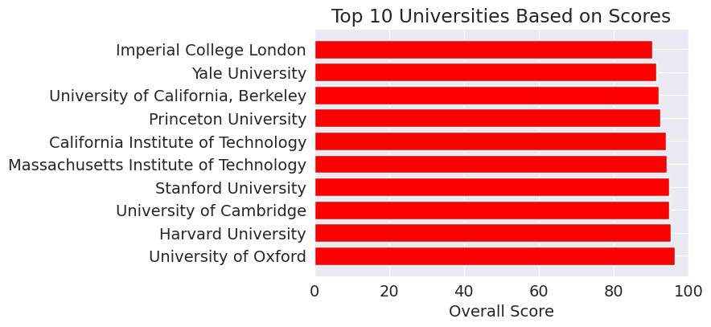

```python
top_10_universities = data["Name of University"][:10]
top_10_scores =data["OverAll Score"][:10]

# Create a bar chart for the top 10 universities
plt.figure(figsize=(6, 4))
plt.barh(top_10_universities[::-1], top_10_scores[::-1], color='red')
plt.xlabel('Overall Score')
plt.title('Top 10 Universities Based on Scores')
plt.xlim(0, 100)  # Customize the score range as needed
plt.gca().invert_yaxis()  # Reverse the order to show the top university at the top
plt.show()
```

The term "Teaching Score" in the context of university rankings typically refers to a metric that evaluates the quality of teaching and the overall educational experience provided by a university. It reflects the institution's commitment to effective pedagogy, faculty-student engagement, and the learning environment. The Teaching Score is often used as a component in global university rankings to assess the educational impact and excellence of universities.

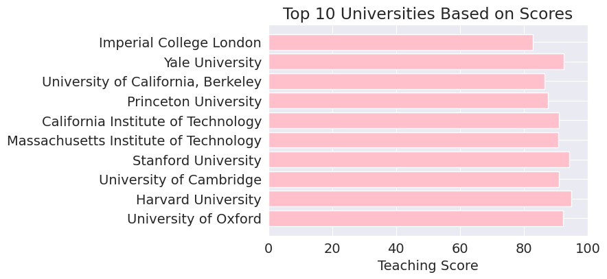

```python
top_10_universities = data["Name of University"][:10]
top_10_scores =data["Teaching Score"][:10]

# Create a bar chart for the top 10 universities
plt.figure(figsize=(6, 4))
plt.barh(top_10_universities[::-1], top_10_scores[::-1], color='pink')
plt.xlabel('Teaching Score')
plt.title('Top 10 Universities Based on Scores')
plt.xlim(0, 100)  # Customize the score range as needed
plt.gca().invert_yaxis()  # Reverse the order to show the top university at the top
plt.show()
```

The "Industry Income Score" in university rankings typically refers to a metric that assesses a university's ability to attract funding and support from industry partners. It reflects the extent to which a university's research activities contribute to and engage with the industrial sector. The Industry Income Score is often used as a component in global university rankings to evaluate the practical impact and relevance of a university's research and its collaboration with the industry.

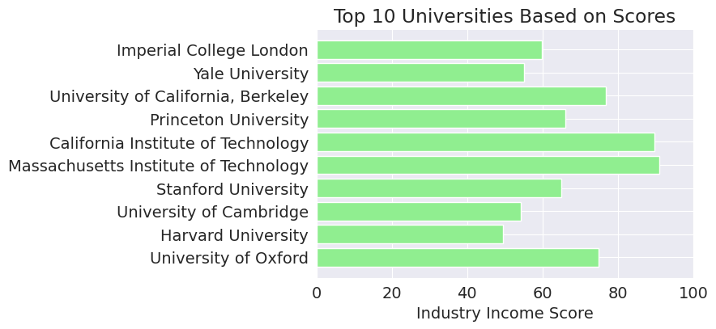

```python
top_10_universities = data["Name of University"][:10]
top_10_scores =data["Industry Income Score"][:10]

# Create a bar chart for the top 10 universities
plt.figure(figsize=(6, 4))
plt.barh(top_10_universities[::-1], top_10_scores[::-1], color='lightgreen')
plt.xlabel('Industry Income Score')
plt.title('Top 10 Universities Based on Scores')
plt.xlim(0, 100)  # Customize the score range as needed
plt.gca().invert_yaxis()  # Reverse the order to show the top university at the top
plt.show()
```

It's important to note that rankings and their components can change over time, and different organizations may use different methodologies to assess international outlook. Always refer to the specific methodology provided by the ranking organization to understand how they calculate the International Outlook Score.

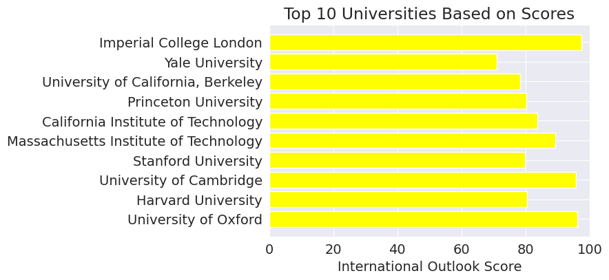

```python
top_10_universities = data["Name of University"][:10]
top_10_scores =data["International Outlook Score"][:10]

# Create a bar chart for the top 10 universities
plt.figure(figsize=(6, 4))
plt.barh(top_10_universities[::-1], top_10_scores[::-1], color='yellow')
plt.xlabel('International Outlook Score')
plt.title('Top 10 Universities Based on Scores')
plt.xlim(0, 100)  # Customize the score range as needed
plt.gca().invert_yaxis()  # Reverse the order to show the top university at the top
plt.show()
```

# **CATEGORICAL and CORRELATION**

In the context of world university rankings, a heatmap can be utilized to visualize both categorical and correlation aspects. Categorical data would involve discrete attributes of universities, such as geographical regions, academic disciplines, or university types. Each cell in the heatmap would represent a specific combination of these categorical variables, and the color intensity within the cell could indicate relevant metrics like ranking positions, enrollment sizes, or research scores.

Correlation in the world university ranking context would involve understanding the linear relationships between quantitative variables, such as academic reputation, faculty-to-student ratios, and research output. A correlation heatmap would display the correlation coefficients between pairs of these numerical variables. The color scale would help identify strong positive correlations, indicating that improvements in one variable align with improvements in another, or strong negative correlations, suggesting an inverse relationship.

In summary, a world university ranking heatmap could effectively capture categorical information like regional or disciplinary distinctions among universities, while also revealing correlations between various quantitative metrics influencing their rankings. This integrated approach allows for a more comprehensive exploration of factors contributing to the overall ranking landscape.

```python
import matplotlib.pyplot as plt
import plotly.express as px
import matplotlib
%matplotlib inline

sns.set_style('darkgrid')
matplotlib.rcParams['font.size'] = 14
matplotlib.rcParams['figure.figsize'] = (9, 5)
matplotlib.rcParams['figure.facecolor'] = '#00000000'
```

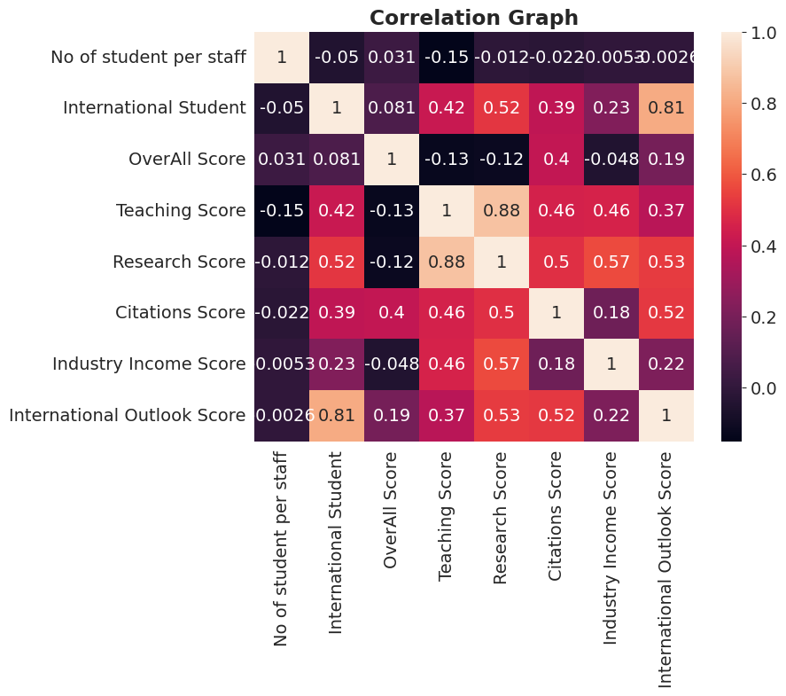

```python
plt.figure(figsize=(8,6))
sns.heatmap(data.corr(), annot=True)
plt.title("Correlation Graph", fontweight="bold")
```

# **Modelling Data Using Linear Regression & Decission Tree**( Working in Process)

Splitting Data Into Training and Testing

```python
from sklearn.compose import ColumnTransformer
from sklearn.model_selection import train_test_split
from sklearn.preprocessing import LabelEncoder
from sklearn.preprocessing import OneHotEncoder
from sklearn.tree import DecisionTreeClassifier
import math
from sklearn.metrics import confusion_matrix
from sklearn.model_selection import RandomizedSearchCV, GridSearchCV
import seaborn as sb
```

```python
data
```

|  | University Rank | Name of University | Country | No of student | No of student per staff | International Student | OverAll Score | Teaching Score | Research Score | Citations Score | Industry Income Score | International Outlook Score |
| --- | --- | --- | --- | --- | --- | --- | --- | --- | --- | --- | --- | --- |
| 0 | 1 | University of Oxford | United Kingdom | 20,965 | 10.6 | 0.42 | 96.4 | 92.3 | 99.7 | 99.0 | 74.9 | 96.2 |
| 1 | 2 | Harvard University | United States | 21,887 | 9.6 | 0.25 | 95.2 | 94.8 | 99.0 | 99.3 | 49.5 | 80.5 |
| 2 | 3 | University of Cambridge | United Kingdom | 20,185 | 11.3 | 0.39 | 94.8 | 90.9 | 99.5 | 97.0 | 54.2 | 95.8 |
| 3 | 3 | Stanford University | United States | 16,164 | 7.1 | 0.24 | 94.8 | 94.2 | 96.7 | 99.8 | 65.0 | 79.8 |
| 4 | 5 | Massachusetts Institute of Technology | United States | 11,415 | 8.2 | 0.33 | 94.2 | 90.7 | 93.6 | 99.8 | 90.9 | 89.3 |
| ... | ... | ... | ... | ... | ... | ... | ... | ... | ... | ... | ... | ... |
| 1692 | 1501+ | Wrocław University of Science and Technology | Poland | 23,657 | 20.3 | 0.06 | 10418.3 | 17.9 | 16.0 | 14.9 | 45.5 | 27.3 |
| 1693 | 1501+ | Yamaguchi University | Japan | 10,724 | 11.1 | 0.07 | 10418.3 | 21.3 | 12.3 | 13.9 | 43.8 | 30.4 |
| 1694 | 1501+ | Yanshan University | China | 38,649 | 13.2 | 0.01 | 10418.3 | 17.2 | 10.9 | 18.3 | 46.9 | 17.0 |
| 1695 | 1501+ | Yeditepe University | Turkey | 17,038 | 28.2 | 0.05 | 10418.3 | 18.8 | 12.2 | 10.5 | 65.7 | 29.6 |
| 1696 | 1501+ | Zonguldak Bülent Ecevit University | Turkey | 28,319 | 25.4 | 0.08 | 10418.3 | 13.2 | 8.2 | 23.5 | 38.9 | 23.1 |

1488 rows × 12 columns

```python
# Function to calculate mid-value from a range string
def calculate_mid_value(range_str):
    # Replace non-standard hyphen with the standard hyphen
    range_str = range_str.replace('–', '-')

    # Split the range string into lower and upper bounds
    range_values = range_str.split('-')

    if len(range_values) == 2:
        lower, upper = map(float, range_values)
        # Calculate the mid-value
        mid_value = (lower + upper) / 2
        return mid_value
    else:
        # Return the original value for invalid formats
        return range_str
```

```python
data.isna().sum()
restColToFillMean = ['No of student', 'International Student', 'OverAll Score']
data[restColToFillMean] = data[restColToFillMean].fillna(data[restColToFillMean].mean())
```

```python
data.isna().sum()
```

```
University Rank                0
Name of University             0
Country                        0
No of student                  0
No of student per staff        0
International Student          0
OverAll Score                  0
Teaching Score                 0
Research Score                 0
Citations Score                0
Industry Income Score          0
International Outlook Score    0
dtype: int64
```

```python
X = data.drop(columns=['Country','Name of University','OverAll Score','Teaching Score','Research Score','Citations Score','Industry Income Score','International Outlook Score'])
y = data['University Rank']
X_train, X_test, y_train, y_test = train_test_split(X, y, test_size=0.2, random_state=42)
# Display the shapes of the resulting datasets
print("X_train shape:", X_train.shape)
print("X_test shape:", X_test.shape)
print("y_train shape:", y_train.shape)
print("y_test shape:", y_test.shape)
```

```
X_train shape: (1190, 4)
X_test shape: (298, 4)
y_train shape: (1190,)
y_test shape: (298,)
```

```python
X_train=X_train.fillna(2)
X_test=X_test.fillna(2)
y_train=y_train.fillna(2)
y_test=y_test.fillna(2)
```

```python
model = DecisionTreeClassifier(criterion = 'entropy')
model
```

```
DecisionTreeClassifier(criterion='entropy')
```